# SS2864Assignment3

William Li

08/12/2020

## Question 1

```r
percentile <- function(x,y) {
  # x is the population distribution
  # y is the evaluation point
  # only works for one evaluation point

  (max(which(sort(append(x,y))  %in% y))-1)/length(x)
}

percentile.v <- function(x,y){
  # x is the distribution
  # y is the evaluation point
  # works for multiple evaluation points
  return(sapply(y,function(g) percentile(x,g)))
}
```

### Test Cases

```r
percentile.v(runif(100000),0.5)
```

```
## [1] 0.50194
```

```r
percentile.v(runif(100000),c(1,2,3,4,5,6,7,8,9)/10)
```

```
## [1] 0.09987 0.19901 0.29827 0.39786 0.49919 0.59977 0.69956 0.80088 0.90044
```

```r
percentile.v(c(0,1),c(0,1))
```

```
## [1] 0.5 1.0
```

```r
percentile.v(c(1,2,3,4,5),c(0,1,1.1,0.9))
```

```
## [1] 0.0 0.2 0.2 0.0
```

## Question 2

```r
# function
matrix.multiply <- function(a,b) {
  # takes in two matrices a and b
  if (nrow(a)!=ncol(b)){
    return('Invalid')
  }

  c <- rep(seq(nrow(a)),nrow(a))

  return(t(matrix(mapply(function(x,y) sum(a[x,]*b[,y]),sort(c),c),ncol=nrow(a))))

}
```

### Test Cases

```r
# 2x2 case
a <- matrix(data=c(1,2,3,4,5,6,7,8),nrow=2)
b <- matrix(data=c(9,8,7,6,5,4,3,2),ncol=2)

matrix.multiply(a,b)
```

```
##      [,1] [,2]
## [1,]  110   46
## [2,]  140   60
```

```r
a %*% b
```

```
##      [,1] [,2]
## [1,]  110   46
## [2,]  140   60
```

```r
# 3x3 case
a <- matrix(data=c(1,2,3,4,5,6,7,8,1,2,3,8),nrow=3)
b <- matrix(data=c(9,8,7,6,5,4,3,2,1,2,3,8),ncol=3)

matrix.multiply(a,b)
```

```
##      [,1] [,2] [,3]
## [1,]  102   46   46
## [2,]  132   60   60
## [3,]  130   58   82
```

```r
a%*%b
```

```
##      [,1] [,2] [,3]
## [1,]  102   46   46
## [2,]  132   60   60
## [3,]  130   58   82
```

```r
# undefined case
a <- matrix(data=c(1,2,3,4,5,6,7,8,1,2,3,8),nrow=2)
b <- matrix(data=c(9,8,7,6,5,4,3,2,1,2,3,8),ncol=3)

matrix.multiply(a,b)
```

```
## [1] "Invalid"
```

## Question 3

```r
set.seed(1337)

pi.estimate <- function(n){

  return(sum(sqrt(runif(n,-1,1)^2  + runif(n,-1,1)^2) < 1)/n *4)

}

pi.estimate(100)
```

```
## [1] 2.92
```

```r
pi.estimate(1000)
```

```
## [1] 3.032
```

```r
pi.estimate(10000)
```

```
## [1] 3.1328
```

## Question 4

```r
sim <- function(n,z,p){
  # function to create mean of n bernoulli random variables
  # and return if 0.8 is within its confid interval

  dat <- rbinom(n,1,p)

  p_hat <- mean(dat)

  r <- z*sqrt(p_hat*(1-p_hat)/n)

  return(p_hat+r>=p & p_hat-r<=p)

}

rep.sim <- function(m,n,z,p){
  # repeat sim function m times and return the average

  results <- replicate(m,sim(n,z,p))

  return(sum(results)/m)
}

set.seed(2333)

# (1)
rep.sim(100,20,1.96,0.8)
```

```
## [1] 0.92
```

```r
# (2)
rep.sim(100,100,1.96,0.8)
```

```
## [1] 0.95
```

The above results agree with the theory. The Central Limit Theorem states that for a random sample of size n of a distribution, the mean of the random sample will follow a normal distribution. However this only holds when n is sufficiently large. The simulation with n=20 was not a sufficiently large n value so it did not match with was we would expect from a normally distributed statistic.

The simulations with n = 100 had 95% of the confidence intervals covering the true p value for a z value of 1.96 which is expected for a normal distribution.

According to the central limit theorem the distribution of the sample mean will converge to a normal distribution as n increases. A rule of thumb is that when n>30 we can approximate the distribution of the sample mean with a normal distribution.

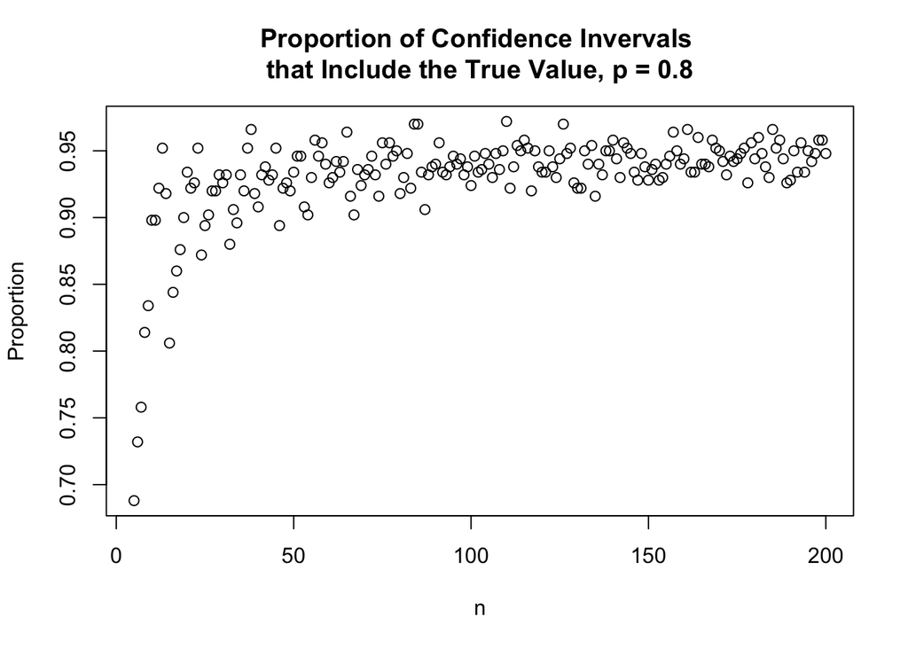

```r
# 2
plot(c(5:200),c(5:200) %>% sapply(function(x) rep.sim(500,x,1.96,0.8)),
     xlab='n',
     main='Proportion of Confidence Invervals \nthat Include the True Value, p = 0.8',
     ylab = 'Proportion')
```